# **Assignment.M.2** - Titanic - Davis Zakary

## **Overview and Directions**

**Overview**

- The Titanic dataset builds confidence with machine learning essentials.
- Read the dataset's history and features in the course [reference.library.Mashup](https://github.com/cosc-526/home.page/blob/069c9488de24d712c642e0f014d37759fc99185d/reference.library.Mashup.data.mine.pdf).
- Follow the analysis stages and tasks to end with predicted survival outcomes.

**Data**

- on course github you're provided 2 data sets for a total three files
- `A:`__ RAW - uncurated passenger data for analysis stages 1 and 2
- `B:`__ train/test - curated kaggle passenger data stages 3 to 5

**Additional Resources** https://davidburn.github.io/notebooks/titanic/Titanic/

### **Stage 1: Data Preparation**

The Titanic dataset has been around for a while, so

- `Q:` Should you trust how others curated it?
- Why is the passenger split at 891 for training? Is that the best?
- Are you confident in the preparation and curation?
- `A:` `It depends!`
- Read a datasets data dictionary and discern who did the work. For instance, was a statistician involved?

Have all authentic questions and lines of inquiry been considered?

- The Titanic raw data set has uncurated `passengers name`
- `Q:` Curious? Has anyone on Kaggle predicted survival based on the # of characters in a name?
- `A:` Probably not! Attempt to observe and question all available data.

Learning: `discern nuances; know what's strange; and perform relentless discovery`

```
Windelov, Mr. Einar
Braund, Mr. Owen Harris
```

#### **Stage 1: Data Preparation**

Tasks.Stage.1 1.1 - import three datasets into dataframe names provided; drop cabin/ticket.  
1.2 - identify missing values in a table.  
1.3 - identify outliers in a table and.or graphic for age variable, use interquartile range

- - q1 = df_train['age'].quantile(0.25)
- - q3 = df_train['age'].quantile(0.75)
- - iqr = q3 - q1  
    1.4 - would you use mean substitution for missing values?  
    => compare age outliers to age without outliers  
    => solution provides a box and whiskers but use whatever you like  
    ==> plt.boxplot(combined_data, labels=['All Data', 'Outliers'], vert=False)

`Useful Resources`

- [pd.DataFrame.dropna](https://pandas.pydata.org/docs/reference/api/pandas.DataFrame.dropna.html#pandas-dataframe-dropna)

#### **Task.1.expected.outcome**

```
==> Data fields with null information:
passengerId      0
survived         0
pclass           0
sex              0
age            177
sibsp            0
parch            0
fare             0
embarked         2
dtype: int64
----------------------------------------

----------------------------------------
Table of outlier values to assess:
     passengerId  survived  pclass   sex   age  sibsp  parch     fare embarked
33            34         0       2  male  66.0      0      0  10.5000        S
54            55         0       1  male  65.0      0      1  61.9792        C
96            97         0       1  male  71.0      0      0  34.6542        C
116          117         0       3  male  70.5      0      0   7.7500        Q
280          281         0       3  male  65.0      0      0   7.7500        Q
456          457         0       1  male  65.0      0      0  26.5500        S
493          494         0       1  male  71.0      0      0  49.5042        C
630          631         1       1  male  80.0      0      0  30.0000        S
672          673         0       2  male  70.0      0      0  10.5000        S
745          746         0       1  male  70.0      1      1  71.0000        S
851          852         0       3  male  74.0      0      0   7.7750        S
----------------------------------------
```

`Visual includes new normalized age value performed in Task.2`

- image shows how outliers can introduce age bias given most people around age 30
- this doesn't indicate you should or shouldn't exclude the values but illustrates why its important to methodically inspect the data

[figure not shown]

#### Tasks.Stage.1.Solution

```python
import seaborn as sns
import pandas as pd
import matplotlib.pyplot as plt
from sklearn.preprocessing import StandardScaler
```

```python
#=>1.1 - import three datasets into dataframe names provided; drop cabin/ticket columns
url_raw = "https://github.com/cosc-526/home.page/raw/main/data.M.2.titanic.raw.data.xls"
url_train = "https://raw.githubusercontent.com/cosc-526/home.page/main/data.M.2.titanic_train.csv"
url_test = "https://raw.githubusercontent.com/cosc-526/home.page/main/data.M.2.titanic_test.csv"
df_raw = pd.read_excel(url_raw)
df_train = pd.read_csv(url_train)
df_test = pd.read_csv(url_test)
```

```python
# 1.2 - identify and sum the missing values per column in a table
df_train.drop(['cabin', 'ticket'], axis=1, inplace=True)
print("==> Data fields with null information:")
print(df_train.isnull().sum())
print("----------------------------------------")
```

```
==> Data fields with null information:
passengerId      0
survived         0
pclass           0
sex              0
age            177
sibsp            0
parch            0
fare             0
embarked         2
dtype: int64
----------------------------------------
```

```python
#=>1.3 - identify outliers in a table and/or graphic for age variable using the interquartile range
q1 = df_train['age'].quantile(0.25)
q3 = df_train['age'].quantile(0.75)
bound_lower = q1 - (1.5 * (q3 - q1))
bound_upper = q3 + (1.5 * (q3 - q1))
print(q1, q3, q3-q1, bound_lower, bound_upper)

outliers = pd.DataFrame(
    df_train[(df_train['age'] < bound_lower) | (df_train['age'] > bound_upper)]
)
print('Outliers identified: ', len(outliers))
print('Total Dataset: ', len(df_train))

print("----------------------------------------")
print("Table of outlier values to assess:")
print(outliers)
print("----------------------------------------")
```

```
20.125 38.0 17.875 -6.6875 64.8125
Outliers identified:  11
Total Dataset:  891
----------------------------------------
Table of outlier values to assess:
     passengerId  survived  pclass   sex   age  sibsp  parch     fare embarked
33            34         0       2  male  66.0      0      0  10.5000        S
54            55         0       1  male  65.0      0      1  61.9792        C
96            97         0       1  male  71.0      0      0  34.6542        C
116          117         0       3  male  70.5      0      0   7.7500        Q
280          281         0       3  male  65.0      0      0   7.7500        Q
456          457         0       1  male  65.0      0      0  26.5500        S
493          494         0       1  male  71.0      0      0  49.5042        C
630          631         1       1  male  80.0      0      0  30.0000        S
672          673         0       2  male  70.0      0      0  10.5000        S
745          746         0       1  male  70.0      1      1  71.0000        S
851          852         0       3  male  74.0      0      0   7.7750        S
----------------------------------------
```

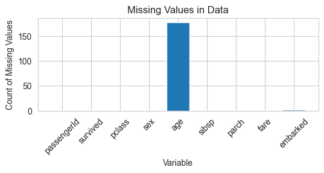

```python
# # Plot missing values (alternatives OK)
missing = df_train.isnull().sum()
plt.figure(figsize=(6, 2))
plt.bar(missing.index, missing)
plt.xticks(rotation=45)
plt.xlabel('Variable')
plt.ylabel('Count of Missing Values')
plt.title('Missing Values in Data')
plt.show()
```

```python
df_train['SetLabel'] = 'All Data'
outliers['SetLabel'] = 'Outliers'
combined_data = pd.concat([outliers, df_train]).reset_index(drop=True)
print(combined_data)
```

```
     passengerId  survived  pclass     sex   age  sibsp  parch     fare  \
0             34         0       2    male  66.0      0      0  10.5000
1             55         0       1    male  65.0      0      1  61.9792
2             97         0       1    male  71.0      0      0  34.6542
3            117         0       3    male  70.5      0      0   7.7500
4            281         0       3    male  65.0      0      0   7.7500
..           ...       ...     ...     ...   ...    ...    ...      ...
897          887         0       2    male  27.0      0      0  13.0000
898          888         1       1  female  19.0      0      0  30.0000
899          889         0       3  female   NaN      1      2  23.4500
900          890         1       1    male  26.0      0      0  30.0000
901          891         0       3    male  32.0      0      0   7.7500

    embarked  SetLabel
0          S  Outliers
1          C  Outliers
2          C  Outliers
3          Q  Outliers
4          Q  Outliers
..       ...       ...
897        S  All Data
898        S  All Data
899        S  All Data
900        C  All Data
901        Q  All Data

[902 rows x 10 columns]
```

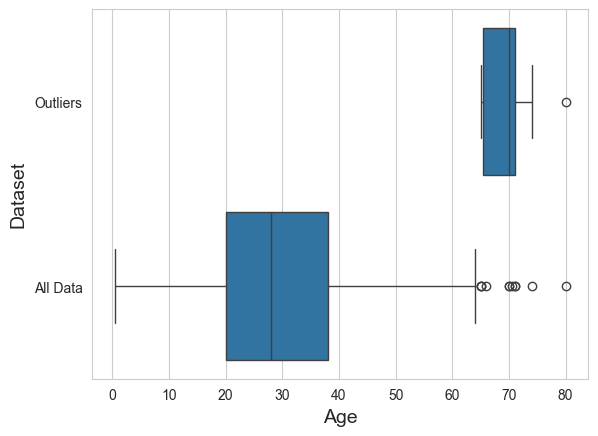

```python
sns.boxplot(
    data=combined_data,
    y='SetLabel',
    x='age'
)
plt.ylabel('Dataset', fontsize=14)
plt.xlabel('Age', fontsize=14)
plt.show()
```

# 1.4 - would you use mean substitution for missing values?

I would not use mean substitution for missing values because this could erroneously reinforce the existing mean. There are 177 records missing the age value, which is **19.8%** of the overall data. By assigning them the mean value, we would alter the gaussian distribution, effectively making it "narrower" on a graph. For example, the IQR and outlier values would be modified. See the code block below for proof.

```python
df_filled = pd.DataFrame(df_train)
df_filled['age'] = df_filled['age'].fillna(df_filled['age'].mean())
print(df_train['age'].quantile(0.25), df_train['age'].quantile(0.75))
print(df_filled['age'].quantile(0.25), df_filled['age'].quantile(0.75))
```

```
20.0 38.0
22.0 35.0
```

#### **`Stage 2: Feature Extraction`**

- `Feature Scaling:` Scale numerical features to ensure similar ranges  
  => techniques like z-score normalization scaling or standardization.
- `Feature Selection:` what features contribute most to the target variable?  
  => techniques like remove redundant features to improve performance and reduce overfitting.

`Tasks.Stage.2`  
=> your response variable is `survival`  
2.1 - read and bookmark scikitlearn [6.3 Preprocessing data](https://scikit-learn.org/stable/modules/preprocessing.html)  
2.2 - perform `one-hot encoding` of categorical variable `sex`; display df header  
2.3 - perform `standarscaler` for a new age variable in df_train

Given the resourcs provided thus far,  
2.4 - `Q:` Would you perform supervised or unsupervised machine learning?  
2.5 - `Q:` What algorithms would you choose to run?

`Useful resources`

- [sklearn.preprocessing.OneHotEncoder](https://scikit-learn.org/stable/modules/generated/sklearn.preprocessing.OneHotEncoder.html#sklearn-preprocessing-onehotencoder)
- [sklearn.preprocessing.standardscaler](https://scikit-learn.org/stable/modules/generated/sklearn.preprocessing.StandardScaler.html#sklearn-preprocessing-standardscaler)

##### **`Tasks.Stage.2.Solution`**

```python
#This code has been provided
#=>2.1 - read and bookmark (https://scikit-learn.org/stable/modules/preprocessing.html)
df_encoded = pd.get_dummies(df_raw, columns=['sex'])
print(df_encoded.head()) #2 new variables created
```

```
   pclass  survived                                             name      age  \
0       1         1                    Allen, Miss. Elisabeth Walton  29.0000
1       1         1                   Allison, Master. Hudson Trevor   0.9167
2       1         0                     Allison, Miss. Helen Loraine   2.0000
3       1         0             Allison, Mr. Hudson Joshua Creighton  30.0000
4       1         0  Allison, Mrs. Hudson J C (Bessie Waldo Daniels)  25.0000

   sibsp  parch  ticket      fare    cabin embarked boat   body  \
0      0      0   24160  211.3375       B5        S    2    NaN
1      1      2  113781  151.5500  C22 C26        S   11    NaN
2      1      2  113781  151.5500  C22 C26        S  NaN    NaN
3      1      2  113781  151.5500  C22 C26        S  NaN  135.0
4      1      2  113781  151.5500  C22 C26        S  NaN    NaN

                         home.dest  sex_female  sex_male
0                     St Louis, MO        True     False
1  Montreal, PQ / Chesterville, ON       False      True
2  Montreal, PQ / Chesterville, ON        True     False
3  Montreal, PQ / Chesterville, ON       False      True
4  Montreal, PQ / Chesterville, ON        True     False
```

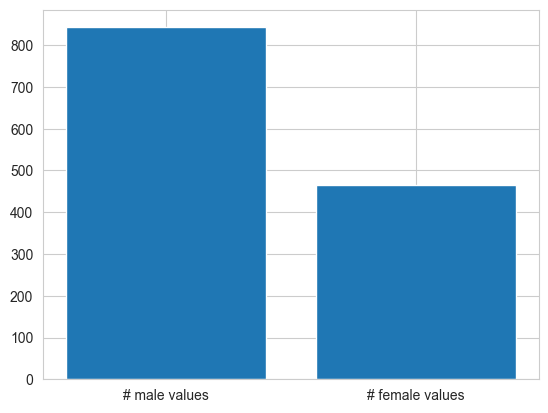

```python
import matplotlib.pyplot as plt
df_encoded = pd.get_dummies(df_raw, columns=['sex'])
counts = [df_encoded['sex_male'].sum(), df_encoded['sex_female'].sum()]
plt.bar(['# male values', '# female values'], counts)
plt.show()
```

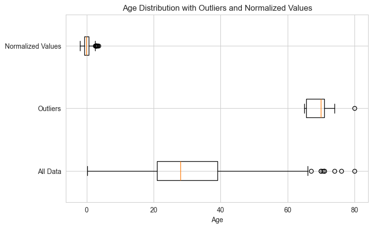

```python
#This code has been provided
#=>2.3 - perform `standarscaler` for a new age variable
# Create DataFrame for all data (excluding outliers)
df_train = df_train[~df_train['age'].isin(outliers['age'])]

scaler = StandardScaler()
all_data = df_raw
all_data.loc[:, 'scaled_new_age'] = scaler.fit_transform(all_data[['age']].values.reshape(-1, 1))

# Exclude missing values from 'age' variable and scaled new age
age_data = all_data['age'].dropna()
scaled_age_data = all_data['scaled_new_age'].dropna()

# combine all age data
combined_data = [age_data, outliers['age'], scaled_age_data]

# Plot all data, outliers, and normalized values in the same graph
plt.figure(figsize=(8, 5))
plt.boxplot(combined_data, labels=['All Data', 'Outliers', 'Normalized Values'], vert=False)
plt.xlabel('Age')
plt.title('Age Distribution with Outliers and Normalized Values')
plt.show()
```

#### **`Stage 3: Machine Learning + Stage 4: Model Evaluation`**

- `Imputation` - either modify unrepaired data, drop it, or dig deeper
- `Data Split` Split the preprocessed dataset into train\test to assess algorithmic effectiveness.
- `Train` using the preprocessed training data.

**`Stage.3.items`**  
3.1 - `logistic regression` on a train \ test of the raw data with

- features = ['sex', 'age', 'fare', 'pclass']
- X = df_train[features]
- y = df_train['survived']

**`Stage.4.items`**  
4.1 Assess accuracy  
4.2 Assess Cross validation

**`Stage.5.items`**  
5.1 Assess confusion matrix

**`Tasks`**

- Task.3 - write a description confirming sequence of machine learning activities
- Task.4 - write a description confirming understanding of evaluation activities
- Task.5 - write a description confirming understanding of visualization activities

### Task 3

In the below code block, we perform the following tasks to go from raw data to a binary classifier:

- Load data from URL
- Feature selection and data transform
  - One-hot encoding of categorical variables (sex)
  - Mean imputation of missing values (age) to prevent 20% loss of training dataset
- Random train-test split, saving 20% for testing. Specifying the `random_state` aids in replication of results
- Create the logistic regression model and fit to the training data
- Use the model to make predictions on the test set.

### Task 4

Now that we have built our binary classifier, it is time to evaluate it. Accuracy is a common metric used in machine learning. For binary classifiers, it is defined as:

$$ Accuracy = \frac{True Positives + True Negatives}{Population} $$

*Note: The provided code rounded this value to the nearest whole number, which discards most of the information. I removed this rounding function*

Our classifier has an accuracy of **0.7988**. This is decent considering the small dataset and limited features available to us.

We also create a confusion matrix. This gives us more detail on what mistakes the model is making. Principally, we are looking to see if there is an even split between false-positives and false-negatives. Some classifiers will be biased towards one error or the other, which is typically not desirable.

It looks like our classifier is balanced, with roughly the same number of false-negatives and false-positives.

### Task 5

In the final code block, we are visualizing the confusion matrix using matplotlib's imshow function. This function is typically used to display image data loaded into a numpy array.

Our "image" only has 4 pixels, so we use nearest neighbor interpolation to fill in the rest of the pixel values. Nearest neighbor creates sharp edges, since each pixel in the graph assumes the whichever of the 4 pixels it is closest to. Of course, this is what we want. For fun, try changing the interpolation value to "bilinear" or "bicubic" to see how it changes the colors.

```python
#this code provided
import pandas as pd
from sklearn.linear_model import LogisticRegression
from sklearn.model_selection import train_test_split
from sklearn.impute import SimpleImputer
from sklearn.metrics import accuracy_score
from sklearn.metrics import confusion_matrix

'''Stage.3.Tasks'''
#=>3.1 perform a logistic regression train \ test on the raw data with
#=>- features = ['sex', 'age', 'fare', 'pclass']
#=>- X = df_train[features]
#=>- y = df_train['survived']

# Load the Titanic dataset
url_train = "https://raw.githubusercontent.com/cosc-526/home.page/main/data.M.2.titanic_train.csv"
df_train = pd.read_csv(url_train)

features = ['sex', 'age', 'fare', 'pclass'] # Select features
X = df_train[features]                      # Prepare features
y = df_train['survived']

X_encoded = pd.get_dummies(X, drop_first=True) # one-hot encoding on categorical

# Handle missing values
imputer = SimpleImputer(strategy='mean')  ## imputing with the mean
X_imputed = pd.DataFrame(imputer.fit_transform(X_encoded), columns=X_encoded.columns)

# Split train/test
X_train, X_test, y_train, y_test = train_test_split(X_imputed, y, test_size=0.2, random_state=42)
X_imputed = pd.DataFrame(imputer.fit_transform(X_encoded), columns=X_encoded.columns)

# Create and train the logistic regression model
model = LogisticRegression()
model.fit(X_train, y_train)

# Make predictions on the test set
y_pred = model.predict(X_test)

'''
'**`Stage.4.Tasks
#=> 4.1 assess accuracy'''

accuracy = accuracy_score(y_test, y_pred)
print("Accuracy:", accuracy)

#=> 4.2 access Cross validation
confusion = confusion_matrix(y_test, y_pred)
print("Confusion Matrix:")
print(confusion)
```

```
Accuracy: 0.7988826815642458
Confusion Matrix:
[[89 16]
 [20 54]]
```

**`Stage 5: Visualization`**

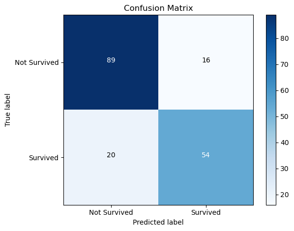

```python
#this code provided
import numpy as np
import matplotlib.pyplot as plt

# Define the confusion matrix
confusion_matrix = np.array(confusion)

# Define the class labels
classes = ['Not Survived', 'Survived']

# Plot the confusion matrix
plt.imshow(confusion_matrix, interpolation='nearest', cmap=plt.cm.Blues)
plt.title('Confusion Matrix')
plt.colorbar()
tick_marks = np.arange(len(classes))
plt.xticks(tick_marks, classes)
plt.yticks(tick_marks, classes)

# Label the matrix cells
thresh = confusion_matrix.max() / 2.
for i, j in np.ndindex(confusion_matrix.shape):
    plt.text(j, i, format(confusion_matrix[i, j], 'd'),
             horizontalalignment="center",
             color="white" if confusion_matrix[i, j] > thresh else "black")

# Add axis labels
plt.xlabel('Predicted label')
plt.ylabel('True label')
plt.tight_layout()

# Show the plot
plt.show()
```